# Homework 10

Arden Moser

2026-02-10

## Instructions

Answer the following questions and complete the exercises in RMarkdown. Please embed all of your code and push your final work to your repository. Your final lab report should be organized, clean, and run free from errors. Remember, you must remove the `#` for the included code chunks to run. Be sure to add your name to the author header above.

Make sure to use the formatting conventions of RMarkdown to make your report neat and clean!

## Background

In the `data` folder, you will find data about shark incidents in California between 1950-2022. The [data](https://catalog.data.gov/dataset/shark-incident-database-california-56167) are from: State of California- Shark Incident Database.

## Load the libraries

```r
library("tidyverse")
library("janitor")
```

## Load the data

Run the following code chunk to import the data. In this chunk, I am removing NA’s.

```r
sharks <-
  read_csv("data/SharkIncidents_1950_2022_220302.csv",
           na=c("NA", "N/A", "Unknown", "NOT COUNTED", "", " ")) %>%
  clean_names()
```

## Questions

1. Are there any “hotspots” for shark incidents in California? Show the top five counties with the most incidents.

```r
sharks %>%
  group_by(county) %>%
  na.omit() %>%
  summarise(number_of_incidents = sum(incident_num)) %>%
  arrange(desc(number_of_incidents)) %>%
  filter(number_of_incidents > 179)
```

```
## # A tibble: 5 × 2
##   county              number_of_incidents
##   <chr>                             <dbl>
## 1 San Luis Obispo                     404
## 2 Humboldt                            389
## 3 Sonoma                              202
## 4 Santa Cruz                          192
## 5 Island - Santa Rosa                 189
```

The top five “hotspots” for shark incidents in California are San Luis Obispo, Humboldt, Sonoma, Santa Cruz, and Santa Rosa Island.  
2. Make a plot that shows the total number of incidents per county.

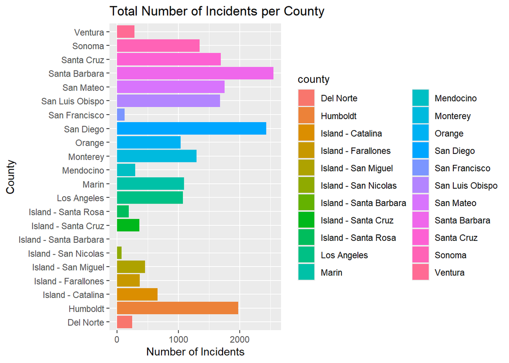

```r
sharks %>%
  ggplot(aes(x = county, y = incident_num, fill = county)) +
  geom_col(na.rm = TRUE) +
  coord_flip() +
  labs(
    title = "Total Number of Incidents per County",
    x = "County",
    y = "Number of Incidents"
  )
```

3. Are there months of the year when incidents are more likely to occur? Make a plot that shows the total number of incidents by month. Which month has the highest number of incidents?

```r
sharks %>%
  group_by(month) %>%
  summarise(total_incident_num = sum(incident_num, na.rm = TRUE)) %>%
  arrange(desc(total_incident_num))
```

```
## # A tibble: 12 × 2
##    month total_incident_num
##    <dbl>              <dbl>
##  1    10               3731
##  2     8               3240
##  3     9               3075
##  4     7               2563
##  5     6               1843
##  6     5               1568
##  7    12               1548
##  8    11               1493
##  9     3                610
## 10     4                510
## 11     1                481
## 12     2                308
```

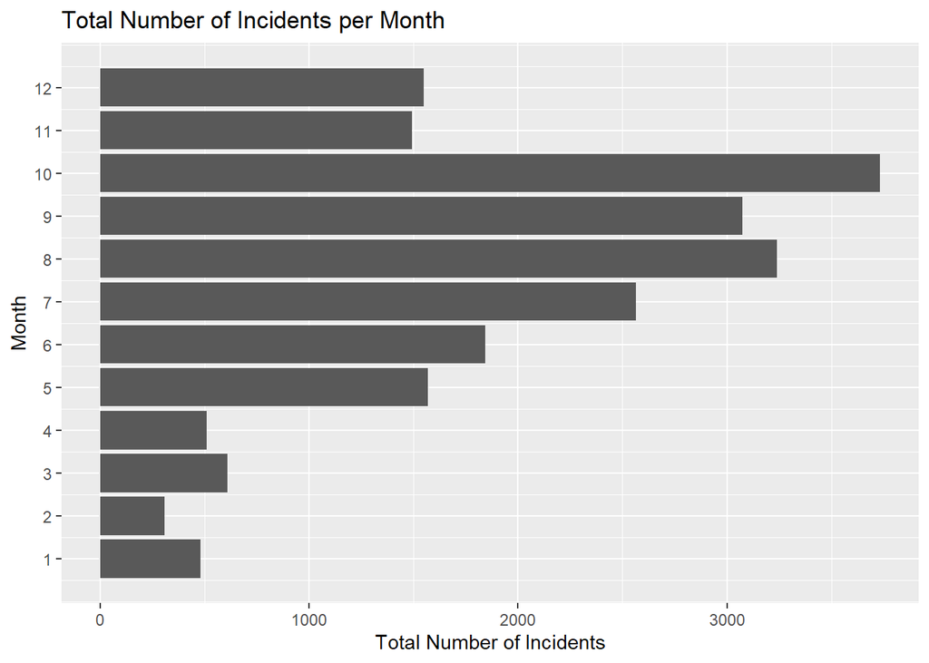

```r
sharks %>%
  ggplot(aes(x = month, y = incident_num)) +
  geom_col(na.rm = TRUE) +
  coord_flip() +
  scale_x_continuous(breaks = c(1, 2, 3, 4, 5, 6, 7, 8, 9, 10, 11, 12)) +
  labs(
    title = "Total Number of Incidents per Month",
    x = "Month",
    y = "Total Number of Incidents"
  )
```

The **10th month** of the year seems to have the highest amount incidents.  
4. Is there a time of day when most attacks occur? Make a plot that shows the total number of incidents by time of day. Which time of day has the highest number of incidents?

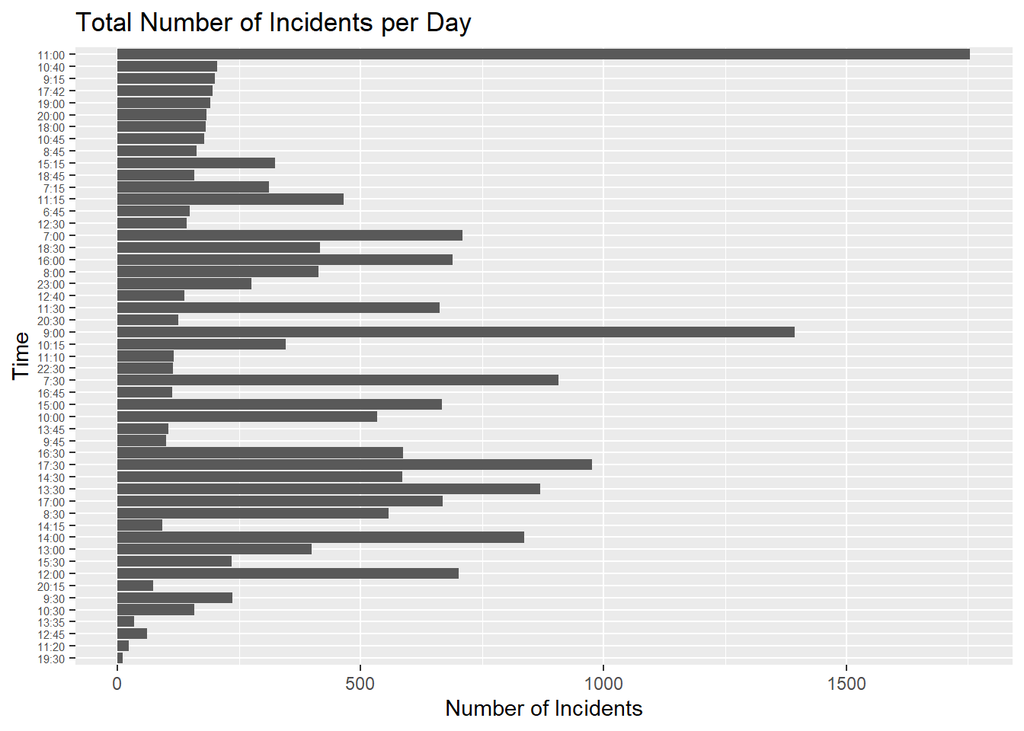

```r
sharks %>%
  filter(time != "early am", time != "afternoon") %>%
  ggplot(aes(x = reorder(time, incident_num), y = incident_num)) +
  geom_col(na.rm =TRUE) +
  coord_flip() +
  theme(axis.text.y = element_text(size = rel(0.65))) +
  labs(
    title = "Total Number of Incidents per Day",
    x = "Time",
    y = "Number of Incidents"
  )
```

Interestingly, the time of day where the most incidents occur is at 11:00.  
5. How do the number and types of injuries compare by county? Make a table that shows the number of injury types by county. Which county has the highest number incidents? (hint: your table should be in wide format)

```r
sharks %>%
  select(county, injury) %>%
  group_by(county, injury) %>%
  summarise(count = n()) %>%
  mutate(total_injuries = sum(count)) %>%
  pivot_wider(
    names_from = injury,
    values_from = count
  ) %>%
  arrange(desc(total_injuries))
```

```
## # A tibble: 22 × 9
## # Groups:   county [22]
##    county       total_injuries minor  none major `minor*` `none*` fatal `major*`
##    <chr>                 <int> <int> <int> <int>    <int>   <int> <int>    <int>
##  1 San Diego                25     8     9     4        1       1     2       NA
##  2 Humboldt                 20     2     9     7        1       1    NA       NA
##  3 San Mateo                19     4    12     1        1      NA     1       NA
##  4 Santa Barba…             19     6     9     2       NA      NA     2       NA
##  5 Marin                    16     4     3     9       NA      NA    NA       NA
##  6 Monterey                 16     2     3     8       NA      NA     2        1
##  7 Santa Cruz               15     3     8     3       NA      NA     1       NA
##  8 Sonoma                   15     1     6     8       NA      NA    NA       NA
##  9 San Luis Ob…             14     1     7     3       NA      NA     3       NA
## 10 Los Angeles              10     6     2    NA       NA      NA     1        1
## # ℹ 12 more rows
```

**San Diego** has the highest number of incidents.  
6. Use the table from #5 to make a plot that shows the total number of incidents by county.

```r
county_table <- sharks %>%
  select(county, injury) %>%
  group_by(county, injury) %>%
  summarise(count = n()) %>%
  mutate(total_injuries = sum(count)) %>%
  pivot_wider(
    names_from = injury,
    values_from = count
  )
```

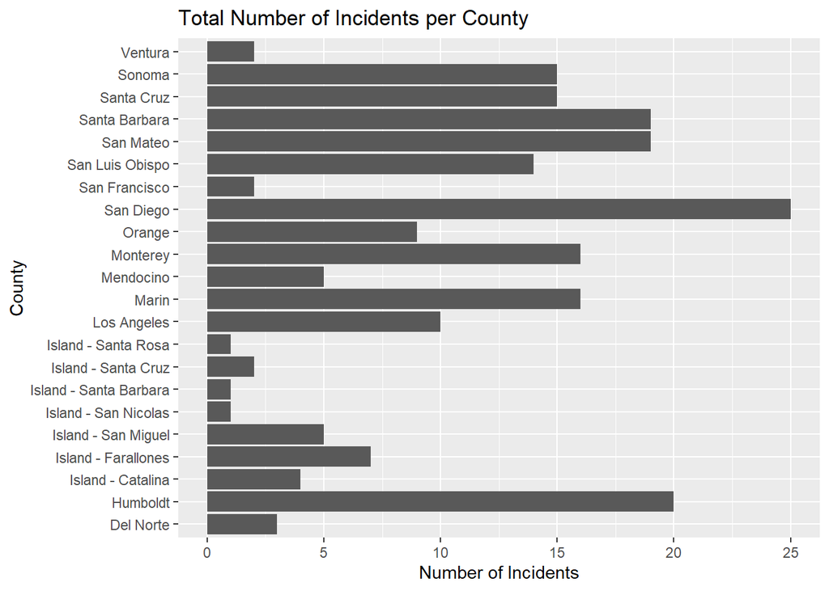

```r
county_table %>%
  ggplot(aes(x = county, y = total_injuries)) +
  geom_col() +
  coord_flip() +
  labs(
    title = "Total Number of Incidents per County",
    x = "County",
    y = "Number of Incidents"
  )
```

7. In the data, `mode` refers to a type of activity. Which activity is associated with the highest number of incidents?

```r
sharks %>%
  select(mode, incident_num) %>%
  group_by(mode) %>%
  summarise(total_incidents = sum(incident_num, na.rm = TRUE)) %>%
  arrange(desc(total_incidents))
```

```
## # A tibble: 8 × 2
##   mode                total_incidents
##   <chr>                         <dbl>
## 1 Surfing / Boarding             9474
## 2 Kayaking / Canoeing            4317
## 3 Freediving                     2501
## 4 Swimming                       1816
## 5 Scuba Diving                   1332
## 6 Paddleboarding                  980
## 7 Hookah Diving                   550
## 8 Walking in shallow                0
```

**Surfing / Boarding** is the activity associated with the highest number of incidents.  
8. Make a plot that compares the number of incidents by activity.

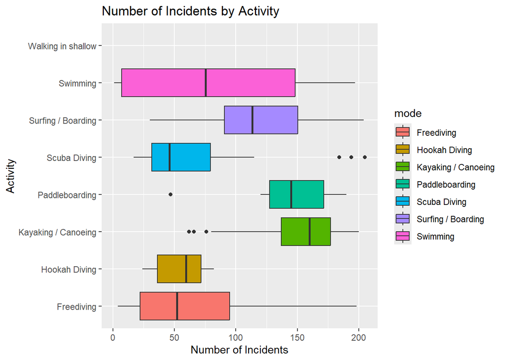

```r
sharks %>%
  ggplot(aes(x = mode, y = incident_num, fill = mode)) +
  geom_boxplot(na.rm = TRUE) +
  coord_flip() +
  labs(
    title = "Number of Incidents by Activity",
    x = "Activity",
    y = "Number of Incidents"
  )
```

9. Which shark species is involved in the highest number of incidents?

```r
sharks %>%
  select(species, incident_num) %>%
  group_by(species) %>%
  summarise(total_incidents = sum(incident_num, na.rm = TRUE)) %>%
  arrange(desc(total_incidents))
```

```
## # A tibble: 12 × 2
##    species      total_incidents
##    <chr>                  <dbl>
##  1 White                  18374
##  2 <NA>                    1447
##  3 Hammerhead               344
##  4 Leopard                  261
##  5 Thresher                 187
##  6 Salmon                   154
##  7 Sevengill                140
##  8 Blue                      63
##  9 Blue*                      0
## 10 Killer Whale               0
## 11 Mako                       0
## 12 blue                       0
```

**Great Whites** are involved in the highest number of incidents.  
10. Are all incidents involving Great White’s fatal? Make a plot that shows the number and types of incidents for Great White’s only.

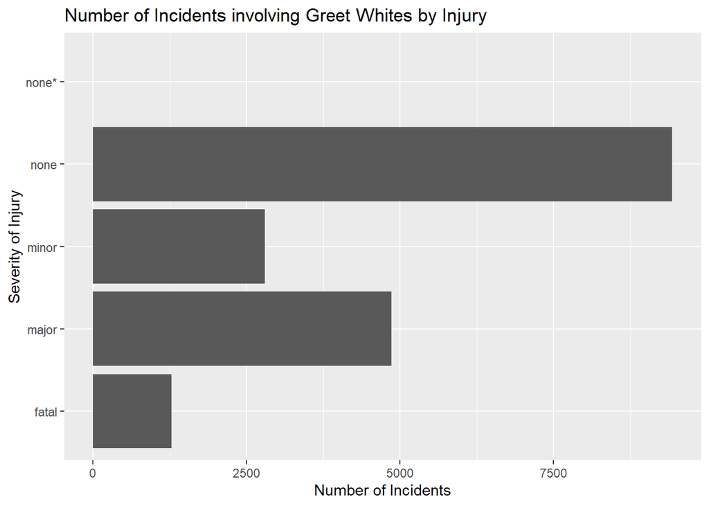

```r
sharks %>%
  filter(species == "White") %>%
  ggplot(aes(x = injury, y = incident_num)) +
  geom_col(na.rm = TRUE) +
  coord_flip() +
  labs(
    title = "Number of Incidents involving Greet Whites by Injury",
    x = "Severity of Injury",
    y = "Number of Incidents"
  )
```

Thankfully, **not all incidents involving Great Whites are fatal.**

## Knit and Upload

Please knit your work as an .html file and upload to Canvas. Homework is due before the start of the next lab. No late work is accepted. Make sure to use the formatting conventions of RMarkdown to make your report neat and clean!